# mlr3 Resampling & Benchmark

9/29/2019 (updated: 2019-10-06)

## Resampling

Review mlr3 resampling methods available.

```r
as.data.table(mlr_resamplings)
```

```
##            key                 params iters
## 1:   bootstrap stratify,repeats,ratio    30
## 2:      custom                            0
## 3:          cv         stratify,folds    10
## 4:     holdout         stratify,ratio     1
## 5: repeated_cv stratify,repeats,folds   100
## 6: subsampling stratify,repeats,ratio    30
```

Additional resampling methods for special use cases are (or will be) available in extension package:

- [mlrspatiotemporal](https://github.com/mlr-org/mlr3spatiotemporal)

### Holdout setup

The train/predict/measure process used in the basics overview is equivalent to the “holdout” resampling method.

```r
res_holdout <- rsmp("holdout")
res_holdout
```

```
## <ResamplingHoldout> with 1 iterations
## * Instantiated: FALSE
## * Parameters: ratio=0.6667
```

The 2/3 default ratio can be changed during during object construction:

```r
rs_holdout <- rsmp("holdout", ratio = 0.75)
rs_holdout
```

```
## <ResamplingHoldout> with 1 iterations
## * Instantiated: FALSE
## * Parameters: ratio=0.75
```

Note:

- `Instantiated: FALSE` means the resampling strategy has not been applied to a dataset yet.

### Holdout instantiation

There are two methods to apply the holdout strategy on a dataset:

1. manually by calling the `.$instantiate()` method on a `Task`

`res_holdout$instantiate(tsk_attr)`

2. automatically by passing the resampling object to `resample()`

`res_rpart <- resample(tsk_attr, lrn_rpart, res_holdout)`

```r
set.seed(3334)
rs_rpart <- resample(tsk_attr, lrn_rpart, rs_holdout)
```

```
## INFO  [09:16:41.398] Applying learner 'classif.rpart' on task 'attrition' (iter 1/1)
```

```r
rs_rpart
```

```
## <ResampleResult> of 1 iterations
## * Task: attrition
## * Learner: classif.rpart
## * Performance: 0.163 [classif.ce]
## * Warnings: 0 in 0 iterations
## * Errors: 0 in 0 iterations
```

```r
rs_rpart$score(msr_auc)
```

```
##             task   task_id               learner    learner_id
## 1: <TaskClassif> attrition <LearnerClassifRpart> classif.rpart
##             resampling resampling_id iteration prediction classif.auc
## 1: <ResamplingHoldout>       holdout         1     <list>   0.6905839
```

```r
set.seed(3334)
rs_ranger <- resample(tsk_attr, lrn_ranger, rs_holdout)
```

```
## INFO  [09:16:41.546] Applying learner 'classif.ranger' on task 'attrition' (iter 1/1)
```

```r
rs_ranger
```

```
## <ResampleResult> of 1 iterations
## * Task: attrition
## * Learner: classif.ranger
## * Performance: 0.149 [classif.ce]
## * Warnings: 0 in 0 iterations
## * Errors: 0 in 0 iterations
```

```r
rs_ranger$score(msr_auc)
```

```
##             task   task_id                learner     learner_id
## 1: <TaskClassif> attrition <LearnerClassifRanger> classif.ranger
##             resampling resampling_id iteration prediction classif.auc
## 1: <ResamplingHoldout>       holdout         1     <list>   0.7481497
```

```r
set.seed(3334)
rs_log <- resample(tsk_attr, lrn_log, rs_holdout)
```

```
## INFO  [09:16:42.491] Applying learner 'classif.log_reg' on task 'attrition' (iter 1/1)
```

```r
rs_log$score(msr_auc)
```

```
##             task   task_id                learner      learner_id
## 1: <TaskClassif> attrition <LearnerClassifLogReg> classif.log_reg
##             resampling resampling_id iteration prediction classif.auc
## 1: <ResamplingHoldout>       holdout         1     <list>   0.8506887
```

### Holdout evaluation

```r
rs_log$prediction()$confusion
```

```
##         truth
## response Yes  No
##      Yes  26  11
##      No   38 293
```

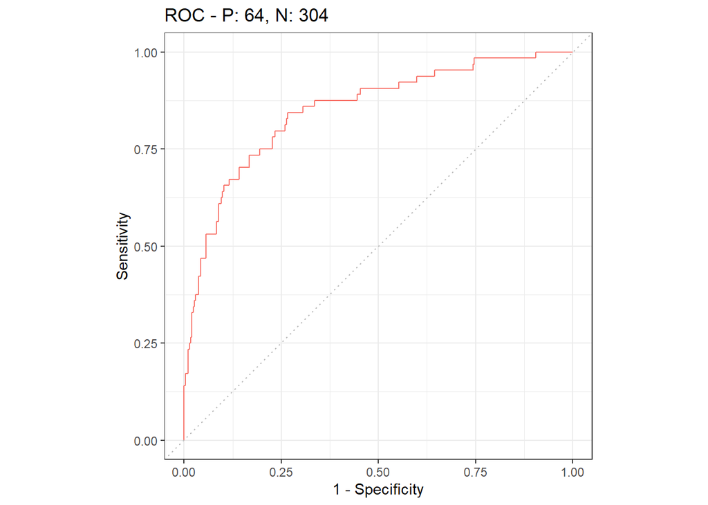

```r
library(precrec)
evaluated_log = evalmod(
    scores = rs_log$prediction()$prob[, tsk_attr$positive],
    label = rs_log$prediction()$truth,
    posclass = tsk_attr$positive
)

ggplot2::autoplot(evaluated_log, curvetype="ROC")
```

## Benchmark

Benchmarking is used to compare the performance of different learners 1 or more tasks and/or using 1 or more resampling strategies.

### Design

The first step in benchmarking is to prepare a design, which is a matrix of settings to execute. Settings are made up `Task`, `Learner`, and `Resampling` objects.

For this example we’re still working with a single task, `tsk_attr`.

```r
rcv3 <- rsmp("repeated_cv", folds = 3, repeats = 5)

learners <- c("classif.featureless", "classif.rpart", "classif.log_reg", "classif.ranger")
learners <- lapply(learners, lrn, predict_type="prob",
                   predict_sets = c("train", "test"))

resamplings <- c(rs_holdout, rcv3)
learners
```

```
## [[1]]
## <LearnerClassifFeatureless:classif.featureless>
## * Model: -
## * Parameters: method=mode
## * Packages: -
## * Predict Type: prob
## * Feature types: logical, integer, numeric, character, factor,
##   ordered
## * Properties: importance, missings, multiclass, selected_features,
##   twoclass
##
## [[2]]
## <LearnerClassifRpart:classif.rpart>
## * Model: -
## * Parameters: xval=0
## * Packages: rpart
## * Predict Type: prob
## * Feature types: logical, integer, numeric, character, factor,
##   ordered
## * Properties: importance, missings, multiclass, selected_features,
##   twoclass, weights
##
## [[3]]
## <LearnerClassifLogReg:classif.log_reg>
## * Model: -
## * Parameters: list()
## * Packages: stats
## * Predict Type: prob
## * Feature types: logical, integer, numeric, character, factor,
##   ordered
## * Properties: twoclass, weights
##
## [[4]]
## <LearnerClassifRanger:classif.ranger>
## * Model: -
## * Parameters: list()
## * Packages: ranger
## * Predict Type: prob
## * Feature types: logical, integer, numeric, character, factor,
##   ordered
## * Properties: importance, multiclass, oob_error, twoclass, weights
```

```r
resamplings
```

```
## [[1]]
## <ResamplingHoldout> with 1 iterations
## * Instantiated: FALSE
## * Parameters: ratio=0.75
##
## [[2]]
## <ResamplingRepeatedCV> with 15 iterations
## * Instantiated: FALSE
## * Parameters: repeats=5, folds=3
```

```r
design <- benchmark_grid(tsk_attr, learners, resamplings)
design
```

```
##             task                     learner             resampling
## 1: <TaskClassif> <LearnerClassifFeatureless>    <ResamplingHoldout>
## 2: <TaskClassif> <LearnerClassifFeatureless> <ResamplingRepeatedCV>
## 3: <TaskClassif>       <LearnerClassifRpart>    <ResamplingHoldout>
## 4: <TaskClassif>       <LearnerClassifRpart> <ResamplingRepeatedCV>
## 5: <TaskClassif>      <LearnerClassifLogReg>    <ResamplingHoldout>
## 6: <TaskClassif>      <LearnerClassifLogReg> <ResamplingRepeatedCV>
## 7: <TaskClassif>      <LearnerClassifRanger>    <ResamplingHoldout>
## 8: <TaskClassif>      <LearnerClassifRanger> <ResamplingRepeatedCV>
```

### Execute Benchmarks

```r
attr_bm
```

```
## <BenchmarkResult> of 64 rows with 8 resampling runs
##  nr   task_id          learner_id resampling_id iters warnings errors
##   1 attrition classif.featureless       holdout     1        0      0
##   2 attrition classif.featureless   repeated_cv    15        0      0
##   3 attrition       classif.rpart       holdout     1        0      0
##   4 attrition       classif.rpart   repeated_cv    15        0      0
##   5 attrition     classif.log_reg       holdout     1        0      0
##   6 attrition     classif.log_reg   repeated_cv    15        0      0
##   7 attrition      classif.ranger       holdout     1        0      0
##   8 attrition      classif.ranger   repeated_cv    15        0      0
```

### Benchmark Evaluate

```r
measures <- list(
    msr("classif.auc", id = "auc_train", predict_sets = "train"),
    msr("classif.auc", id = "auc_test", predict_sets = "test")
)

tab = attr_bm$aggregate(measures)
ranks = tab[, .(learner_id, resampling_id, rank_train = rank(-auc_train), rank_test = rank(-auc_test)), by = task_id]


ranks[, .(mrank_train = mean(rank_train), mrank_test = mean(rank_test)),
      by = .(learner_id, resampling_id)][order(mrank_test)]
```

```
##             learner_id resampling_id mrank_train mrank_test
## 1:     classif.log_reg   repeated_cv         4.0        1.0
## 2:     classif.log_reg       holdout         3.0        2.0
## 3:      classif.ranger   repeated_cv         1.0        3.0
## 4:      classif.ranger       holdout         2.0        4.0
## 5:       classif.rpart   repeated_cv         5.0        5.0
## 6:       classif.rpart       holdout         6.0        6.0
## 7: classif.featureless       holdout         7.5        7.5
## 8: classif.featureless   repeated_cv         7.5        7.5
```